# Demonstration page of R Markdown in combination with corporate theming

Flash Gordon, consultant economist

9 September 2017

[figure not shown]

DRAFT

# 1 Executive Summary

Lorem ipsum dolor sit amet, orci in pharetra, ac facilisis ac vel pulvinar justo tempus dignissim, porta quisque interdum et. Venenatis feugiat etiam ut convallis. Nulla donec hendrerit sit sed imperdiet sed, euismod aptent, nec at. Suscipit per, vitae, enim erat consequat pellentesque posuere. Turpis quis sed ante interdum donec amet platea. Quis faucibus eu dapibus est nibh, nisl eros venenatis inceptos finibus nibh. Commodo dui sed, tristique porttitor donec sed sociis dictumst. Ut pharetra adipiscing ac nibh. Neque, himenaeos orci sed morbi convallis dignissim. Mattis sed et proin mauris sed varius facilisis fringilla in. Mauris leo leo, varius senectus curae eu nulla venenatis dictumst phasellus ut. Eu donec eget eget pretium amet blandit commodo nostra commodo nunc. Sed in, nec. Morbi in nunc sollicitudin faucibus, curabitur mus commodo. Erat penatibus netus metus eu auctor rutrum.

# 2 Purpose

This is basically just a demo of how to deal with a few issues with making R Markdown files comply with corporate styling - fonts, logo, heading sizes and colours, etc. The [source code of the mini-project that builds this file is on GitHub](https://github.com/ellisp/rmarkdown-corporate-eg).

The features include:

- logo in the top right of the document, and modify the title’s width to allow for it
- heading styles and fonts in the html
- fonts and corporate colours used in the graphics
- document builds successfully even if the project is on a mapped network drive which usually causes problems with RStudio Server and Pandoc

# 3 Analysis

## 3.1 Data

We found this data from [MBIE’s website](http://www.mbie.govt.nz/info-services/sectors-industries/tourism/tourism-research-data/monthly-regional-tourism-estimates/data-download). MBIE is the Ministry of Business, Innovation and Employment. This dataset represents estimated spend per month by tourists, broken down by product and country of origin.

## 3.2 Findings

### 3.2.1 Raw data

We see a very strong seasonal pattern, and also that people spend a lot on accommodation, food and beverage, and retail.

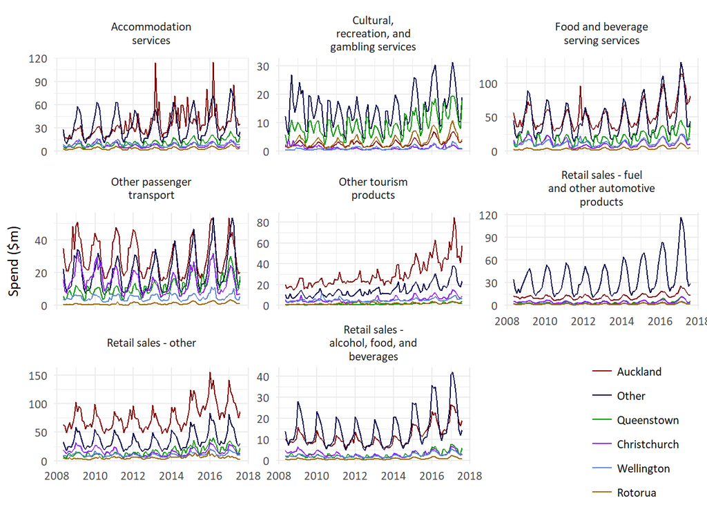

### 3.2.2 Seasonally adjusted

Some of the pattern is obscured by the strongly seasonal element. There are more tourists in summer than winter in New Zealand. We can use statistical methods to adjust for the seasonality and focus more on the trend. NOte the big spike in food and beverage sales in Auckland in particular at the time of the 2011 Rugby World Cup. Also not challenges with seasonal adjustment of accommodation spend in Auckland. We could consider using more sophisticated methods to understand what is going on here.

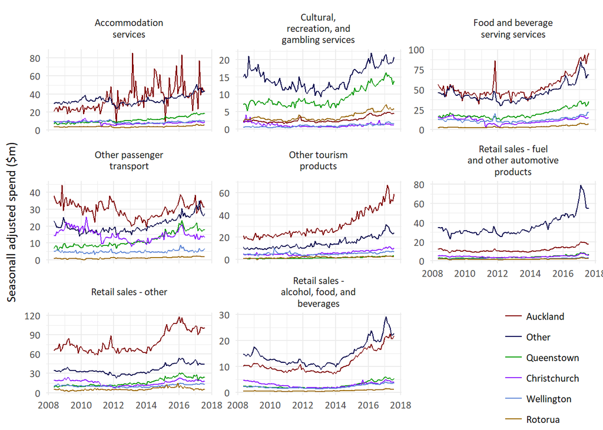

### 3.2.3 Food and Bev versus accommodation

We get some interesting patterns if we compare the percentage of total tourism spend on accommodation compared to food and beverage. The sking location of Ruapehu stands out as having much more spend on accommodation and relatively little on food and beverage. However, this may reflect the data collection process - if food and beverages are purchased from tourist’s hotels, it will show up as accommodation:

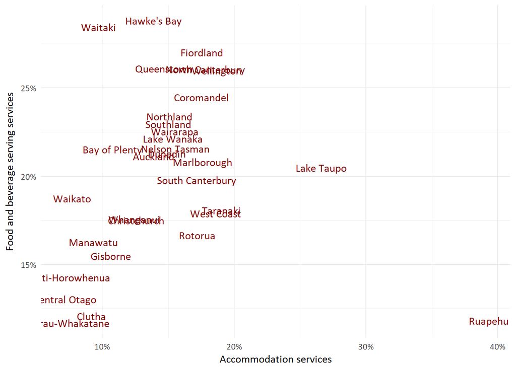